# assignment07

#### 3. Improvement

1. Adding additional predictors. This includes adding variables such as score, number of employees and census information of the neighborhood.
2. Change algorithms. The current model uses classification model. We could use knn model alternatively as restaurants located in the same community may have similar attributes.
3. Adding hyperparameters. Model quality can be improved by making predictions based on the k-nearest neighbor.

#### 4. Variable Importance

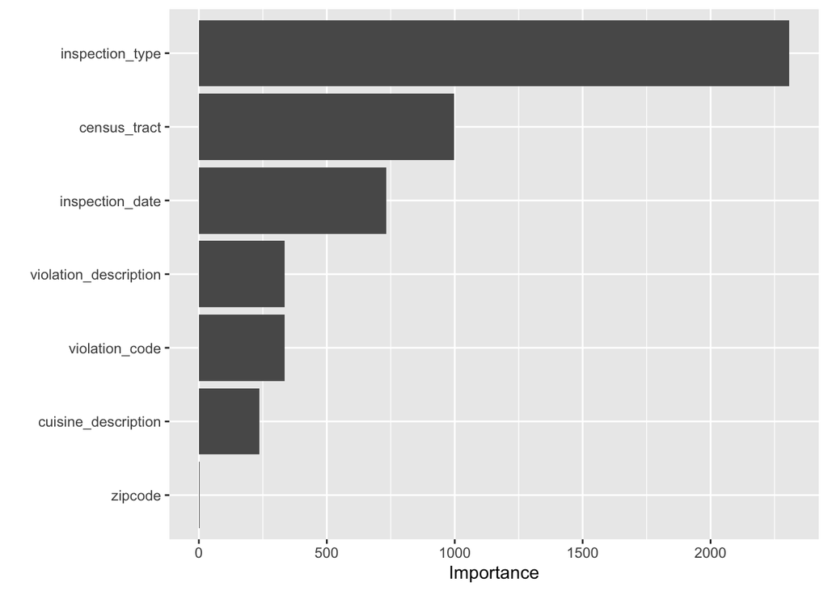

```r
library(vip)

cart_fit %>%
  pull_workflow_fit() %>%
  vip(num_features = 10)
```

This bar graph lists for variable importance. In other words, it counts the frequency of how often a variable is incorporated in the split. An overall evaluation of importance is the sum of goodness of split measures. While we should be aware that if there are any variables duplicates each other, such as violation code and violation description, which undermines importance evaluation for both variables.

#### 5. Application

The ombudsman could use this as a tool to prevent corruption in the restaurants rating. Since the model very sensitive in identifying the non-A results, restaurants are unlikely to bribe the inspectors to get an A when they are actually not.

## Exercise 02 (3 points)

```r
# wrangle data frame
Chicago_estimation <- Chicago %>%
  slice(1:5678)

Chicago_implementation <- Chicago %>%
  slice(5679:5698) %>%
  select(-ridership)
```

#### 1. Convert date into a useable variable

```r
Chicago_estimation <- Chicago_estimation %>%
          mutate(weekday = wday(date), label = TRUE,
                 month = month(date), label = TRUE,
                 yearday = yday(date), label = TRUE)
```

#### 2. Set up a testing environment

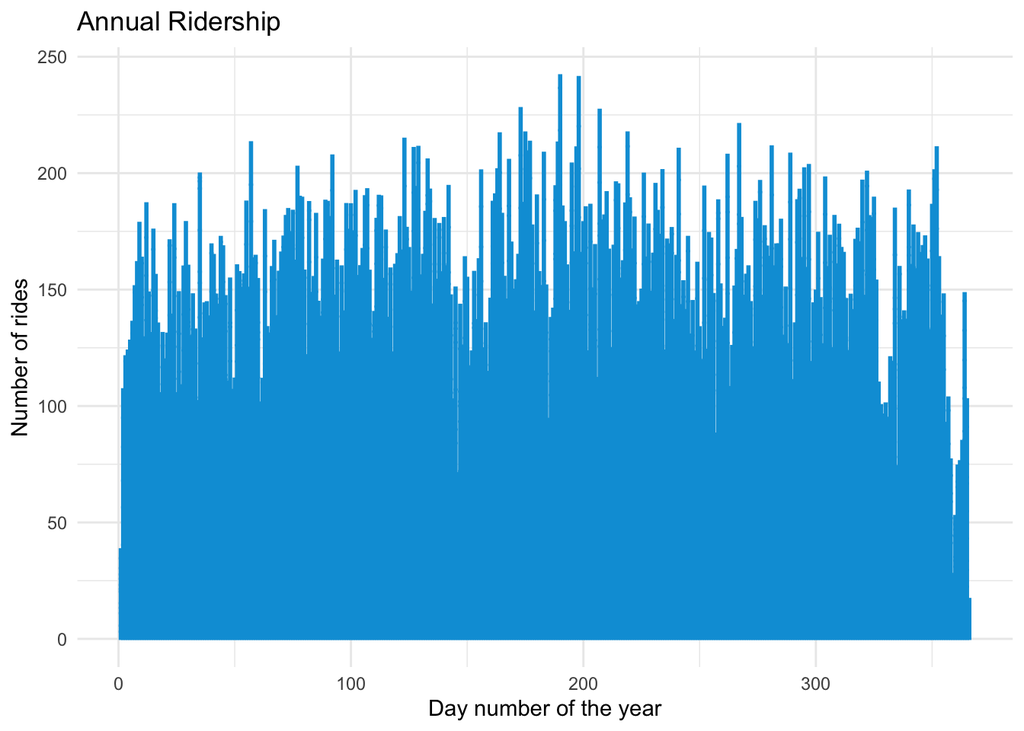

```r
set.seed(20211101)

# create a split object
Chicago_estimation_split <- initial_split(data = Chicago_estimation)

# create the training and testing data
Chicago_estimation_train <- training(x = Chicago_estimation_split)
Chicago_estimation_test <- testing(x = Chicago_estimation_split)

# EDA1
Chicago_estimation_train %>%
  ggplot() +
  geom_col(aes(x = yearday, y = ridership),
           color = "#009FDA") +
  labs(title = "Annual Ridership",
       x = "Day number of the year",
       y = "Number of rides") +
  theme_minimal()
```

```r
# create 10-fold
folds <- vfold_cv(data = Chicago_estimation_train, v = 10)
```

#### 3. Test different approaches

##### 3.1 knn + hyperparameter

```r
# create a recipe
knn_recipe <-
  recipe(formula = ridership ~ ., data = Chicago_estimation_train) %>%
  step_normalize(ridership) %>%
  step_holiday(date) %>%
  step_dummy(all_nominal_predictors())

# see the outcome data
bake(prep(knn_recipe, training = Chicago_estimation_train), new_data = Chicago_estimation_test)
```

```
## # A tibble: 1,420 × 57
##    Austin Quincy_Wells Belmont Archer_35th Oak_Park Western Clark_Lake Clinton
##     <dbl>        <dbl>   <dbl>       <dbl>    <dbl>   <dbl>      <dbl>   <dbl>
##  1  1.50         8.35     4.72       2.09     1.43     3.34      15.7    2.40
##  2  1.50         7.62     4.72       2.06     1.42     3.27      15.6    2.42
##  3  1.53         8.06     4.8        2.14     1.45     3.49      15.5    2.45
##  4  1.55         7.78     4.63       2.08     1.39     3.18      15.5    2.45
##  5  1.58         8.26     4.64       2.15     1.45     3.27      15.7    2.37
##  6  1.49         7.53     4.58       1.96     1.32     3.11      14.9    2.29
##  7  1.52         8.14     4.68       2.07     1.44     3.29      15.6    2.43
##  8  0.679        0.942    2.24       0.706    0.401    1.05       2.43   0.742
##  9  1.60         8.13     4.77       2.21     1.45     3.45      15.7    2.37
## 10  1.33         7.25     4.66       2.11     1.39     3.28      15.4    2.43
## # … with 1,410 more rows, and 49 more variables: Merchandise_Mart <dbl>,
## #   Irving_Park <dbl>, Washington_Wells <dbl>, Harlem <dbl>, Monroe <dbl>,
## #   Polk <dbl>, Ashland <dbl>, Kedzie <dbl>, Addison <dbl>,
## #   Jefferson_Park <dbl>, Montrose <dbl>, California <dbl>, temp_min <dbl>,
## #   temp <dbl>, temp_max <dbl>, temp_change <dbl>, dew <dbl>, humidity <dbl>,
## #   pressure <dbl>, pressure_change <dbl>, wind <dbl>, wind_max <dbl>,
## #   gust <dbl>, gust_max <dbl>, percip <dbl>, percip_max <dbl>, …
```

```r
##### run the model - regression ######

# create a model
knn_mod <-
  nearest_neighbor(neighbors = tune()) %>%
  set_engine(engine = "kknn") %>%
  set_mode(mode = "regression")

# create a workflow
knn_workflow  <-
  workflow() %>%
  add_model(spec = knn_mod) %>%
  add_recipe(recipe = knn_recipe)

# create a tuning grid
knn_grid <- tibble(neighbors = seq(from = 1, to = 15, by = 5))

# estimate with resampling
knn_res <-
  knn_workflow %>%
  tune_grid(resample = folds,
            grid = knn_grid,
            control = control_grid(save_pred = TRUE),
            metrics = metric_set(rmse))

# select best model (k = 11)
knn_best <- knn_res %>%
            select_best()

### create a new model ###
knn_mod_11 <-
  nearest_neighbor(neighbors = 11) %>%
  set_engine(engine = "kknn") %>%
  set_mode(mode = "regression")

# create a new workflow
knn_workflow_11  <-
  workflow() %>%
  add_model(spec = knn_mod_11) %>%
  add_recipe(recipe = knn_recipe)

# fit resample
knn_fit_rs <-
  knn_workflow_11 %>%
  fit_resamples(resample = folds)

# collect metrics
collect_metrics(knn_fit_rs)
```

```
## # A tibble: 2 × 6
##   .metric .estimator  mean     n std_err .config
##   <chr>   <chr>      <dbl> <int>   <dbl> <chr>
## 1 rmse    standard   0.435    10  0.0148 Preprocessor1_Model1
## 2 rsq     standard   0.810    10  0.0123 Preprocessor1_Model1
```

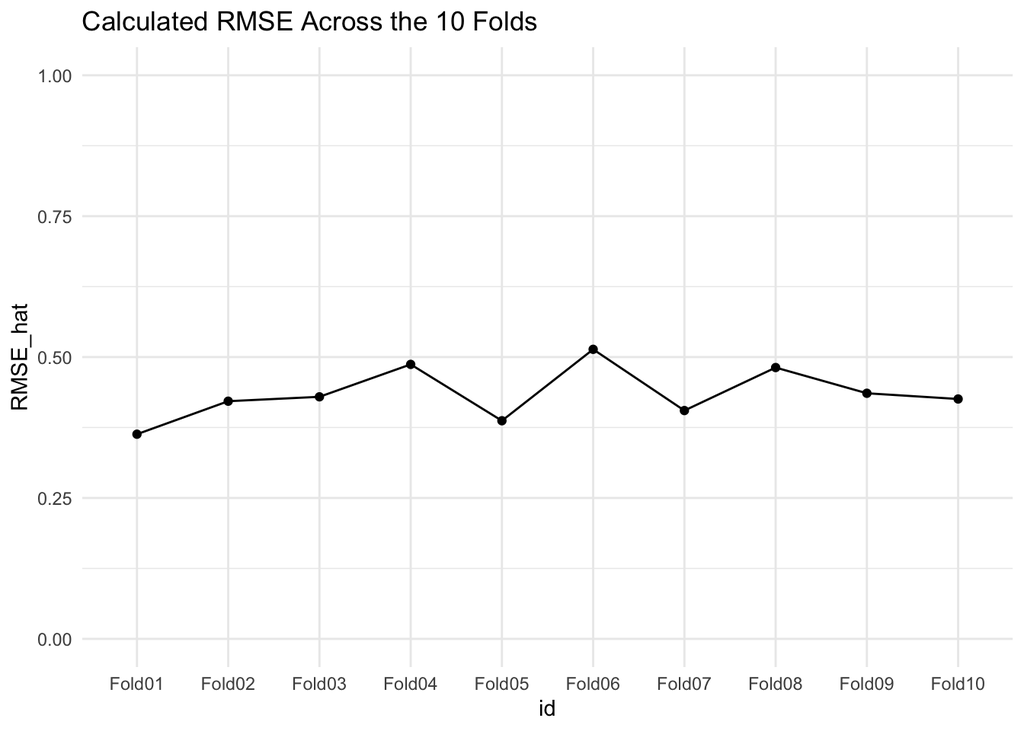

```r
# plot rmse
collect_metrics(knn_fit_rs, summarize = FALSE) %>%
  filter(.metric == "rmse") %>%
  ggplot(aes(id, .estimate, group = .estimator)) +
  geom_line() +
  geom_point() +
  scale_y_continuous(limits = c(0, 1)) +
  labs(title = "Calculated RMSE Across the 10 Folds",
       y = "RMSE_hat") +
  theme_minimal()
```

##### 3.2 Decision Tree

```r
# remove non-numeric columns
Chicago_estimation_train <- Chicago_estimation_train %>%
                                 select(-date, -label)
# create a recipe
cart_recipe <-
  recipe(formula = ridership ~ ., data = Chicago_estimation_train) %>%
  # dummy encode categorical predictors
  step_dummy(all_nominal_predictors()) %>%
  # center and scale predictors
  step_center(all_predictors()) %>%
  step_scale(all_predictors()) %>%
  # drop near zero variance predictors
  step_nzv(all_predictors())

# create a cart model object
cart_mod <-
  decision_tree() %>%
  set_engine(engine = "rpart") %>%
  set_mode(mode = "regression")

# create a workflow
cart_workflow  <-
  workflow() %>%
  add_model(spec = cart_mod) %>%
  add_recipe(recipe = cart_recipe)

# estimate with resampling
cart_res <-
  cart_workflow %>%
  tune_grid(resample = folds,
            control = control_grid(save_pred = TRUE),
            metrics = metric_set(rmse))

# fit resample
cart_fit_rs <-
  cart_workflow %>%
  fit_resamples(resample = folds)

# collect metrics
collect_metrics(cart_fit_rs)
```

```
## # A tibble: 2 × 6
##   .metric .estimator  mean     n std_err .config
##   <chr>   <chr>      <dbl> <int>   <dbl> <chr>
## 1 rmse    standard   2.70     10  0.109  Preprocessor1_Model1
## 2 rsq     standard   0.830    10  0.0130 Preprocessor1_Model1
```

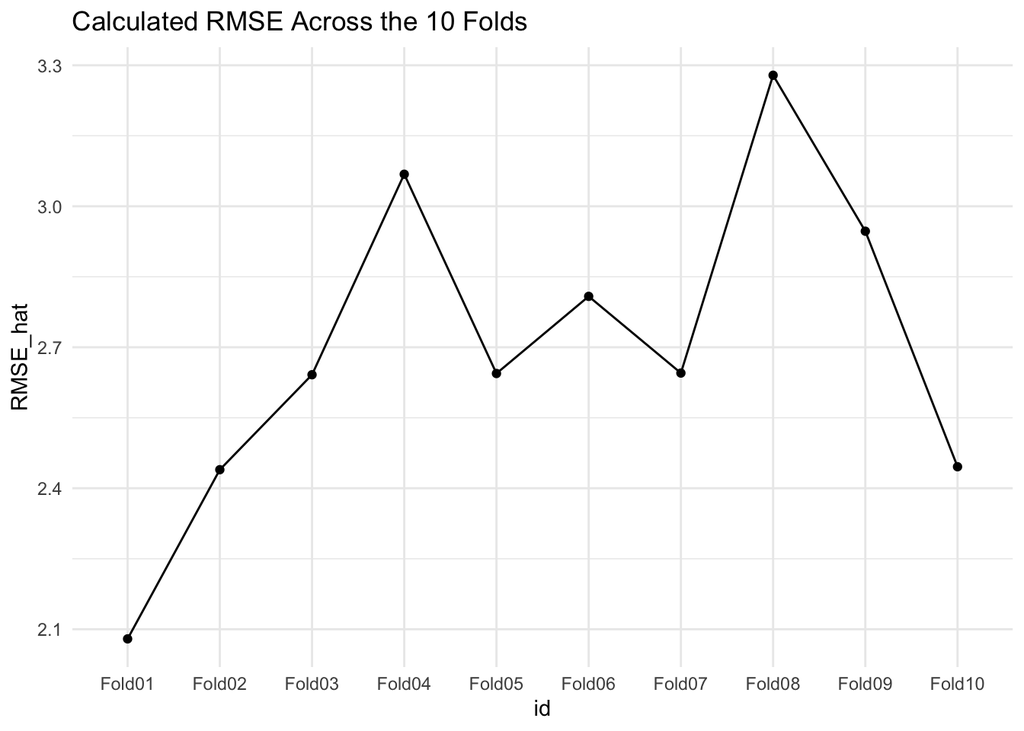

```r
# plot rmse
collect_metrics(cart_fit_rs, summarize = FALSE) %>%
  filter(.metric == "rmse") %>%
  ggplot(aes(id, .estimate, group = .estimator)) +
  geom_line() +
  geom_point() +
  labs(title = "Calculated RMSE Across the 10 Folds",
       y = "RMSE_hat") +
  theme_minimal()
```

##### 3.3 Random Forest

```r
# create a recipe
rf_recipe <-
  recipe(formula = ridership ~ ., data = Chicago_estimation_train) %>%
  # dummy encode categorical predictors
  step_dummy(all_nominal_predictors()) %>%
  # center and scale predictors
  step_center(all_predictors()) %>%
  step_scale(all_predictors()) %>%
  # drop near zero variance predictors
  step_nzv(all_predictors())

# create a cart model object
rf_mod <-
  rand_forest() %>%
  set_engine(engine = "randomForest") %>%
  set_mode(mode = "regression")

# create a workflow
rf_workflow  <-
  workflow() %>%
  add_model(spec = rf_mod) %>%
  add_recipe(recipe = rf_recipe)

# estimate with resampling
rf_res <-
 rf_workflow %>%
  tune_grid(resample = folds,
            control = control_grid(save_pred = TRUE),
            metrics = metric_set(rmse))

# fit resample
rf_fit_rs <-
  rf_workflow %>%
  fit_resamples(resample = folds)

# collect metrics
collect_metrics(rf_fit_rs)
```

```
## # A tibble: 2 × 6
##   .metric .estimator  mean     n std_err .config
##   <chr>   <chr>      <dbl> <int>   <dbl> <chr>
## 1 rmse    standard   2.13     10 0.0758  Preprocessor1_Model1
## 2 rsq     standard   0.895    10 0.00760 Preprocessor1_Model1
```

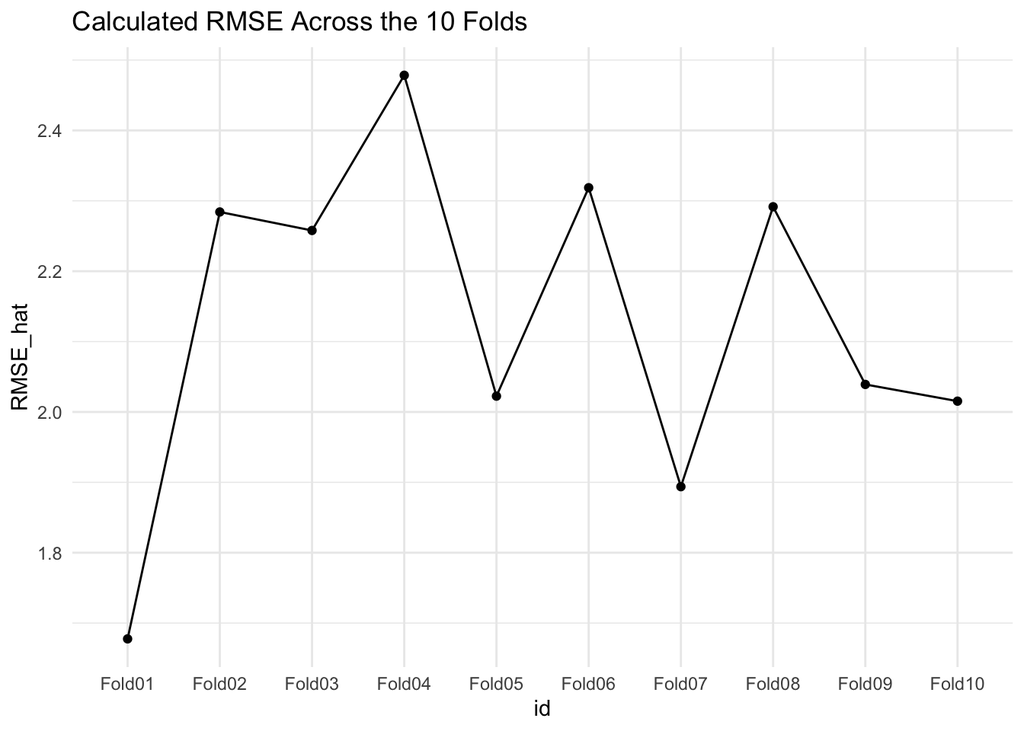

```r
# plot rmse
collect_metrics(rf_fit_rs, summarize = FALSE) %>%
  filter(.metric == "rmse") %>%
  ggplot(aes(id, .estimate, group = .estimator)) +
  geom_line() +
  geom_point() +
  labs(title = "Calculated RMSE Across the 10 Folds",
       y = "RMSE_hat") +
  theme_minimal()
```

#### 4. Estimate the out-of-sample error rate

```r
# prediction
knn_mod_best <-
  nearest_neighbor(neighbors = 11) %>%
  set_engine(engine = "kknn") %>%
  set_mode(mode = "regression")

# fit the model
knn_fit_best <- knn_mod_best %>%
  fit(formula = ridership ~ ., data = Chicago_estimation_train)

# make predictions using traning data
predictions_best <- bind_cols(
  Chicago_estimation_test,
  predict(object = knn_fit_best, new_data = Chicago_estimation_test),
)

# calculate rmse
rmse(data = predictions_best, truth = ridership, estimate = .pred)
```

```
## # A tibble: 1 × 3
##   .metric .estimator .estimate
##   <chr>   <chr>          <dbl>
## 1 rmse    standard        3.06
```

#### 5. Implement the final model

```r
print(Chicago_implementation)

library(vip)

Chicago_implementation %>%
  vip(num_features = 10)

predictions_implement <- bind_cols(
  Chicago_implementation,
  predict(object = knn_fit_best, new_data = Chicago_implementation),
)
```

[output not shown]

## Exercise 03 (6 points)

#### 1. Set up

**a. Briefly describe the data set**

The target variable is the duration of a bike ride. Two types of clustered estimators are included in the data set. We include geospacial and time-relevant variables to predict the duration of a ride to assess usage pattern to better targer potential customers.

```r
# load dataset
bike <- read_csv("202108-capitalbikeshare-tripdata.csv",
                  show_col_types = FALSE) %>%
        mutate(duration = (ended_at - started_at)/60,
               day = day(ymd_hms(started_at)),
               hour = hour(ymd_hms(started_at)),
               month = month(ymd_hms(started_at), label = TRUE),
               year = year(ymd_hms(started_at)),
               weekday = wday(ymd_hms(started_at), label = TRUE),
               yearday = yday(ymd_hms(started_at))) %>%
        select(-ride_id, -started_at, -ended_at,
               -start_station_name, -end_station_name)
```

```r
set.seed(20211121)

# create a split object
bike_split <- initial_split(data = bike)

# create the training and testing data
bike_train <- training(x = bike_split)
bike_test <- testing(x = bike_split)

# create 3-fold
folds <- vfold_cv(data = bike_train, v = 3)
```

**b. Use data visualization to perform an exploratory data analysis**

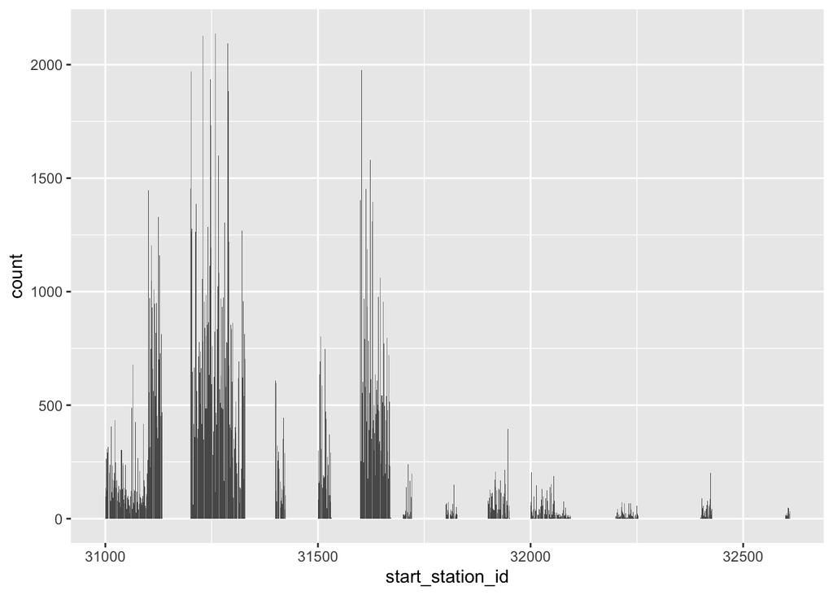

```r
# EDA1
bike_train %>%
  group_by(start_station_id) %>%
  summarize(count = n()) %>%
  filter(count < 10000) %>%
  ggplot() +
  geom_col(aes(x = start_station_id, y = count))
```

[figure not shown]

```r
# each station has dramatic different departure numbers

# EDA2
bike_train %>%
  group_by(rideable_type, member_casual) %>%
  ggplot() +
  geom_col(aes(x = member_casual, y = as.factor(duration))) +
  theme_minimal()
```

#### 2. Come up with Models

**a. Processing data**

```r
# select numeric variables of interest
bike_train <- bike_train %>%
  mutate(duration = as.numeric(duration),
         weekday = as.numeric(weekday)) %>%
  select(-rideable_type, -member_casual, -month)

# standardize the variables
bike_train_numeric <- bike_train %>%
  mutate_all(.funs = ~ scales::rescale(.x))

# correlation
cor_bike_train <- cor(bike_train_numeric)
print(cor_bike_train)
```

```
##                  start_station_id end_station_id    start_lat    start_lng
## start_station_id                1             NA           NA           NA
## end_station_id                 NA              1           NA           NA
## start_lat                      NA             NA  1.000000000 -0.106524655
## start_lng                      NA             NA -0.106524655  1.000000000
## end_lat                        NA             NA           NA           NA
## end_lng                        NA             NA           NA           NA
## duration                       NA             NA -0.008602662 -0.012100464
## day                            NA             NA  0.027460556 -0.005462976
## hour                           NA             NA -0.026549741 -0.007674897
## year                           NA             NA           NA           NA
## weekday                        NA             NA  0.003297415  0.009868498
## yearday                        NA             NA  0.027460556 -0.005462976
##                  end_lat end_lng     duration          day         hour year
## start_station_id      NA      NA           NA           NA           NA   NA
## end_station_id        NA      NA           NA           NA           NA   NA
## start_lat             NA      NA -0.008602662  0.027460556 -0.026549741   NA
## start_lng             NA      NA -0.012100464 -0.005462976 -0.007674897   NA
## end_lat                1      NA           NA           NA           NA   NA
## end_lng               NA       1           NA           NA           NA   NA
## duration              NA      NA  1.000000000 -0.004681018  0.003407287   NA
## day                   NA      NA -0.004681018  1.000000000 -0.021372388   NA
## hour                  NA      NA  0.003407287 -0.021372388  1.000000000   NA
## year                  NA      NA           NA           NA           NA    1
## weekday               NA      NA  0.002452180  0.060671384  0.020109463   NA
## yearday               NA      NA -0.004681018  1.000000000 -0.021372388   NA
##                      weekday      yearday
## start_station_id          NA           NA
## end_station_id            NA           NA
## start_lat        0.003297415  0.027460556
## start_lng        0.009868498 -0.005462976
## end_lat                   NA           NA
## end_lng                   NA           NA
## duration         0.002452180 -0.004681018
## day              0.060671384  1.000000000
## hour             0.020109463 -0.021372388
## year                      NA           NA
## weekday          1.000000000  0.060671384
## yearday          0.060671384  1.000000000
```

```r
# co-variate
cov_bike_train <- cov(bike_train_numeric)
print(cov_bike_train)
```

```
##                  start_station_id end_station_id     start_lat     start_lng
## start_station_id               NA             NA            NA            NA
## end_station_id                 NA             NA            NA            NA
## start_lat                      NA             NA  6.445397e-03 -5.548367e-04
## start_lng                      NA             NA -5.548367e-04  4.209014e-03
## end_lat                        NA             NA            NA            NA
## end_lng                        NA             NA            NA            NA
## duration                       NA             NA -3.383296e-06 -3.845692e-06
## day                            NA             NA  6.700479e-04 -1.077187e-04
## hour                           NA             NA -4.687717e-04 -1.095063e-04
## year                           NA             NA  0.000000e+00  0.000000e+00
## weekday                        NA             NA  9.075323e-05  2.194850e-04
## yearday                        NA             NA  6.700479e-04 -1.077187e-04
##                  end_lat end_lng      duration           day          hour year
## start_station_id      NA      NA            NA            NA            NA   NA
## end_station_id        NA      NA            NA            NA            NA   NA
## start_lat             NA      NA -3.383296e-06  6.700479e-04 -4.687717e-04    0
## start_lng             NA      NA -3.845692e-06 -1.077187e-04 -1.095063e-04    0
## end_lat               NA      NA            NA            NA            NA   NA
## end_lng               NA      NA            NA            NA            NA   NA
## duration              NA      NA  2.399743e-05 -6.969383e-06  3.670855e-06    0
## day                   NA      NA -6.969383e-06  9.237265e-02 -1.428568e-03    0
## hour                  NA      NA  3.670855e-06 -1.428568e-03  4.836737e-02    0
## year                  NA      NA  0.000000e+00  0.000000e+00  0.000000e+00    0
## weekday               NA      NA  4.118114e-06  6.321487e-03  1.516144e-03    0
## yearday               NA      NA -6.969383e-06  9.237265e-02 -1.428568e-03    0
##                       weekday       yearday
## start_station_id           NA            NA
## end_station_id             NA            NA
## start_lat        9.075323e-05  6.700479e-04
## start_lng        2.194850e-04 -1.077187e-04
## end_lat                    NA            NA
## end_lng                    NA            NA
## duration         4.118114e-06 -6.969383e-06
## day              6.321487e-03  9.237265e-02
## hour             1.516144e-03 -1.428568e-03
## year             0.000000e+00  0.000000e+00
## weekday          1.175242e-01  6.321487e-03
## yearday          6.321487e-03  9.237265e-02
```

In this exercise, I will pick rmse to decide which model is the best. The data is process at the beginning and in this recipe below.

**b. Briefly outline what your predictors**

Redundant predictors are removed when importing the data. For example, station is recorded in both name and id, only id was chosen to analyze in this exercise.

The geospatial data is highly relevant to its surrounding neighborhood. It serves as a good predictor to the duration of a ride. Time relevant variables, such as weekday and hour are great to predict peak hours and bike usage.

1. algorithm: K-means

```r
# install.packages("Boom")
library(Boom)

set.seed(20211121)

# predict two clusters
bike_train_kmeans <- kmeans(bike_train_numeric,
                     centers = 3,
                     nstart = 10)

# show result table
tidy(bike_train_kmeans) %>%
  knitr::kable(digits = 2)
```

[output not shown]

2. algorithm: PCA

```r
# run PCA
bike_pca <-
  prcomp(bike_train_numeric)

# extract the principle components
bikes_pcs <- bike_pca %>%
             .$x  %>%
             as_tibble()

# combine the pcs to the to previous dataset
bike_pcs <- bind_cols(
  select(duration, start_station_id, start_lat, start_lng),
  votes_pcs
)
```

### 4. Interpretation

**a. Interpret the results**

The result is very useful in application. From the EDA, we learned that each station has a very distinct departure statistics. The popularity of a one station is mainly depend on two factors. One is location. The other is the time of the day/week. Our clustered model well captures these two aspects, thus making a good application of clustering analysis.

**b. Specification quality**

**c. Specification quality**

**d. Suggest a specification**

We can add more add auxiliary information from other data sets. This includes proximity to a metro station, the weather of the day/hour, and temperature etc.

**e. Model usefulness**

The models used here are not very useful. The predictions could have been better with supervised machine learning, as our goal is to predict known values and we could further confirms our model accuracy.